**Download** (right-click, save target as ...) this page as a Jupyterlab notebook from: [EX-2](http://54.243.252.9/ce-3305-webroot/5-Exams/EX2/EX2.ipynb)

# CE 3305 Engineering Fluid Mechanics Summer 2022 Exam 2

**LAST NAME, FIRST NAME**

**R00000000**

### Purpose :

Demonstrate ability to apply fluid mechanics and problem solving principles covering topics such as: Bernoulli's equation, Conservation of Mass, Control Volume Analysis, Conservation of Linear Momentum.

### Problem 1

[figure not shown]

Figure 1. Schematic of cylindrical tank with a hole in the side

A cylindrical water tank with diameter of 60 cm is shown in Figure 1. Find the time required for the water surface to drop from a depth of 3.0 m to 0.5 m.

# sketch(s) here

[figure not shown]

```python
# list known quantities
```

```python
# list unknown quantities
```

```python
# governing principles
```

```python
# solution (step-by-step)
import math
h_begin=3.0
h_end=0.5
D_t = 60
D_j = 3
A_t = 0.25*math.pi*D_t**2
A_j = 0.25*math.pi*D_j**2
g = 9.81
time = -(2*(math.sqrt(h_end)-math.sqrt(h_begin)))*(A_t/A_j)*(1/math.sqrt(2*g))
print("Time to Drain = ",round(time,1)," seconds")
```

```
Time to Drain =  185.1  seconds
```

```python
# discussion
```

### Problem 2:

# sketch here

[figure not shown]

```python
# list known quantities
```

```python
# list unknown quantities
```

```python
# governing principles
```

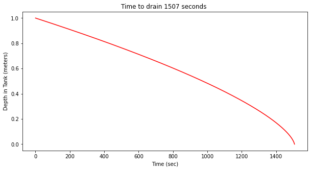

```python
# solution (step-by-step)
# Numerical Approximation by forward difference
import math
# input values
g = 9.81
D = 1.00
d = 0.01
h_start = 1.0
h_end = 0.0
# prototype function
def Atank(D,h):
    Atank = 0.25*math.pi*(D*math.sin( 0.5*math.acos((D-2*h)/D) ))**2
    return(Atank)

def dhdt(g,h,D,d):
    atank = Atank(D,h) # tank surface area
    adrain = 0.25*math.pi*d**2
    num = -math.sqrt(2*g*h)*adrain
    den = atank
    dhdt = num/den
    return(dhdt)
# finite difference model
dt = 1
hnow = h_start
etime = 0
time = [] # list to store times
depth = [] # list to store tank depth
time.append(etime)
depth.append(hnow)
while hnow > h_end:
    dh = dhdt(g,hnow,D,d)*dt  # estimate change in depth
    hnew = hnow + dh # increment for new depth
    etime = etime +dt # increment for new time
    if hnew >= h_end:
        hnow = hnew
        depth.append(hnew)
        time.append(etime)
    else:
        hnow = 0
        depth.append(0)
        time.append(etime)
        break
#print(hnow,etime,dh,at)

import matplotlib.pyplot as plt # the python plotting library
plottitle ='Time to drain ' + str(round(etime,1)) + ' seconds '
mydata = plt.figure(figsize = (10,5)) # build a square drawing canvass from figure class
plt.plot(time, depth, c='red') # basic line plot
plt.xlabel('Time (sec)')
plt.ylabel('Depth in Tank (meters)')
plt.title(plottitle)
plt.show()
```

```python
# discussion
```

### Problem 3

What is the velocity of the flow of water in leg B of the tee in Figure 3

[figure not shown]

Figure 3. Water flow in T connection

# sketch(s) here

[figure not shown]

```python
# list known quantities
```

```python
# list unknown quantities
```

```python
# governing principles
```

```python
# solution (step-by-step) (Put the plot here, or in discussion)
```

```python
# discussion
```

### Problem 4

Figure 4 is a vertical bend in a pipe with a 2 foot diameter. It conveys water ($\rho=62.4 \frac{lbm}{ft^3}$) at a rate of 31.4 $\frac{ft^3}{s}$.

[figure not shown]

Figure 4. Vertical pipe bend

The pressure $p_1$ is 10 $psi$ at the lower end of the bend where the elevation is 100 feet. The pressure $p_2$ is 8.5 $psi$ at the upper end of the bend where the elevation is 103 feet.

What is the vertical component of force that must be exherted by the anchor block on the bend to hold it in place? The bend itself weighs 300 lbf and the length $L$ is 4 feet.

# sketch(s) here

[figure not shown]

```python
# list known quantities
```

```python
# list unknown quantities
```

```python
# governing principles
```

```python
# solution (step-by-step)
```

```python
# discussion
```

### Problem 5

A firehose on a boat is producing a 4-in. -diameter, horizontal, water jet with a speed of V= 60 mph. The boat is held stationary by a cable attached to a pier. The water temperature is 50oF. What is the tension in the cable?

# sketch(s) here

[figure not shown]

```python
# list known quantities
```

```python
# list unknown quantities
```

```python
# governing principles
```

```python
# solution (step-by-step)
```

```python
# discussion
```